# 8 – Time series

Make sure to install the packages “TTR” and “forecast”

```r
#install.packages("TTR")
#install.packages("forecast")
```

Also, don’t forget to load these libraries

```r
library(TTR)
library(forecast)
```

Observe the following time series, the weekly demand for some product.

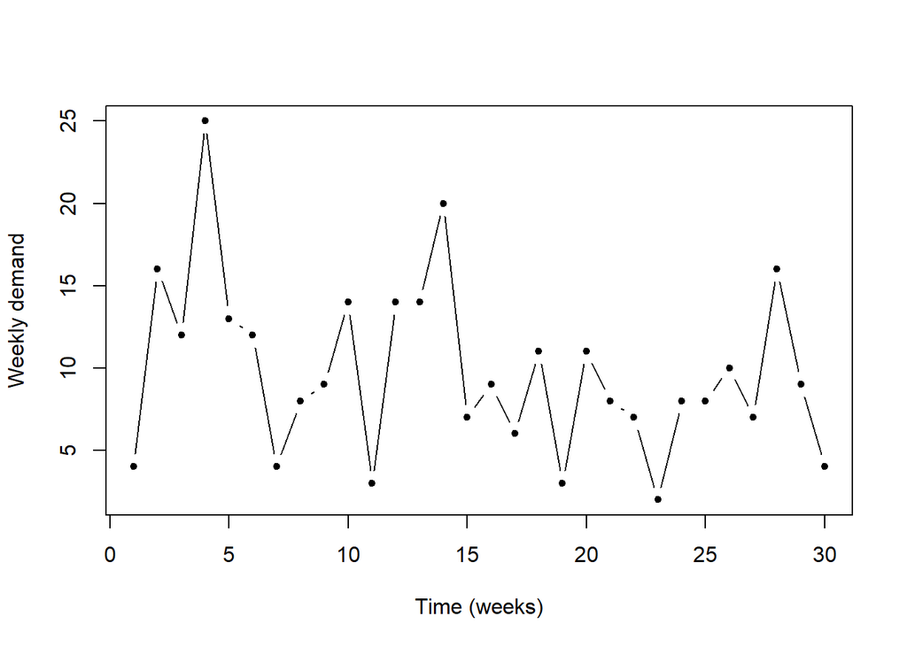

```r
weekly_demand <- c(
  4, 16, 12, 25, 13, 12, 4,  8, 9, 14,
  3, 14, 14, 20,  7,  9, 6, 11, 3, 11,
  8,  7,  2,  8,  8, 10, 7, 16, 9,  4
)
demand_ts <- ts(weekly_demand)
plot.ts(demand_ts, type = 'b', pch = 20,
        xlab = "Time (weeks)",
        ylab = "Weekly demand")
```

## Time series models

In the chart below, we attempt to model observed values with a constant function $X_t = b + \epsilon_t$. As an estimate for $b$, we take the average of the first observations. We can basically use our own judgement to choose how many.

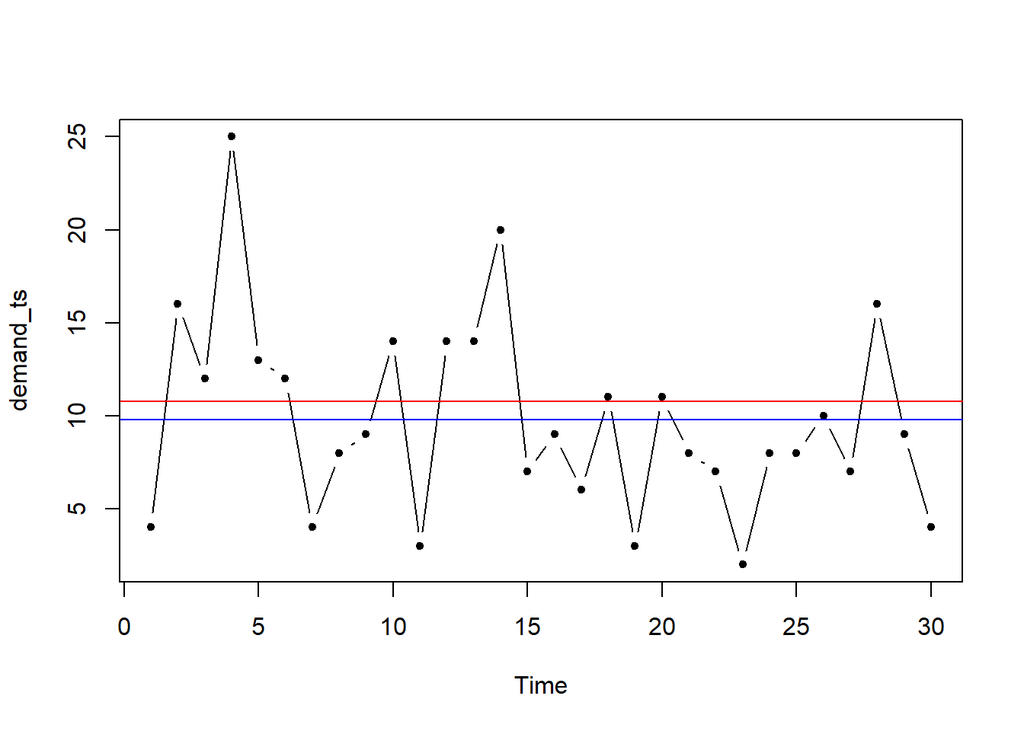

```r
b_est_20 <- mean(weekly_demand[1:20]) # the first 20 observations
b_est_30 <- mean(weekly_demand[1:30]) # the first 30 observations
plot.ts(demand_ts, type = 'b', pch = 20)
abline(h = b_est_20, col = 'red')
abline(h = b_est_30, col = 'blue')
```

If we want to model these values with a linear function $X_t = b_0 + b_1 t + \epsilon_t$, we can use a technique we actually already used in another context: linear regression.

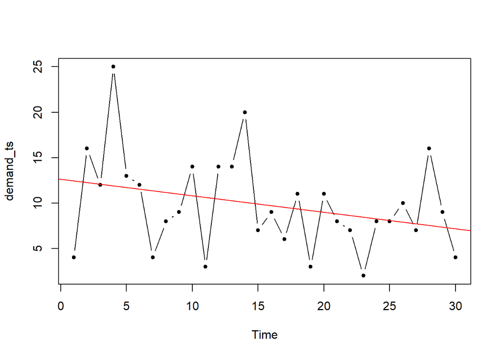

```r
week <- 1:length(weekly_demand)
demand_lm <- lm(weekly_demand ~ week)
plot.ts(demand_ts, type = 'b', pch = 20)
abline(demand_lm, col = 'red')
```

The previous estimate doesn’t seem useful. If we use the regression line to make a forecast of weekly demand in the future, we would expect that the demand will soon drop to zero.

## Moving average

We basically need a method that takes the last observations into account, but forgets observations after some time. Older observations may no longer be representative of the current demand. Moving averages are such methods.

### Simple Moving Average

$X_t = \frac{1}{m} \cdot \sum_{i=k}^t x_i$ with $k=t-m+1$

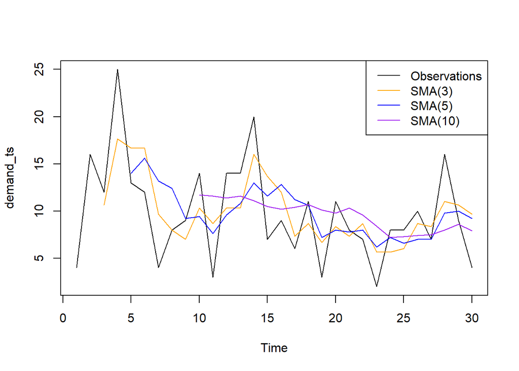

```r
sma_3 <- SMA(x = demand_ts, n = 3)
sma_5 <- SMA(x = demand_ts, n = 5)
sma_10 <- SMA(x = demand_ts, n = 10)

plot.ts(demand_ts)
lines(sma_3, col = 'orange')
lines(sma_5, col = 'blue')
lines(sma_10, col = 'purple')
legend("topright", lty = 1,
       c("Observations", "SMA(3)", "SMA(5)", "SMA(10)"),
       col = c("black", "orange", "blue", "purple"))
```

### Exponential Moving Average

$X_t = \alpha \cdot x_t + (1 - \alpha) \cdot X_{t-1}$

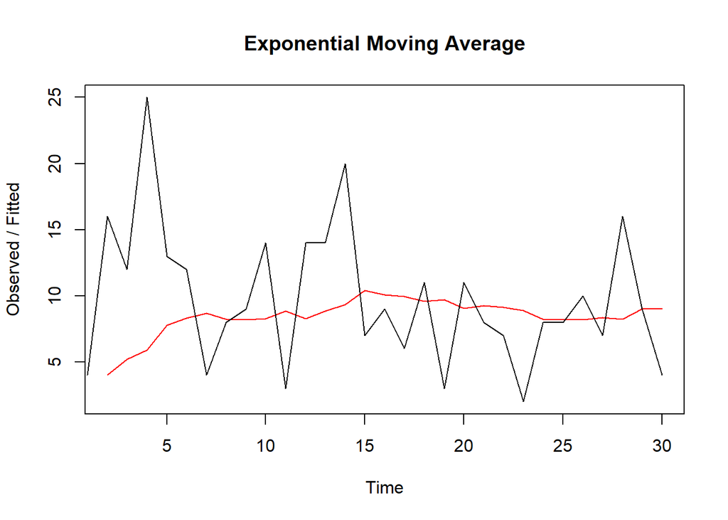

```r
# Play with the value of alpha. What happens if alpha is close to 1?
ema <- HoltWinters(demand_ts, alpha = 0.1, beta = FALSE, gamma = FALSE)
plot(ema, main = "Exponential Moving Average")
```

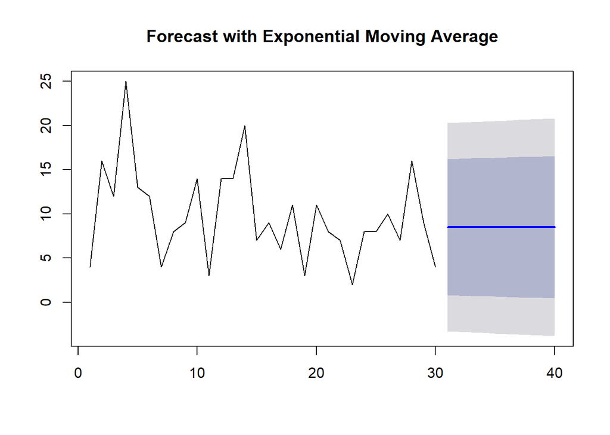

```r
ema_fc <- forecast(ema, h = 10)
plot(ema_fc, main = "Forecast with Exponential Moving Average")
```

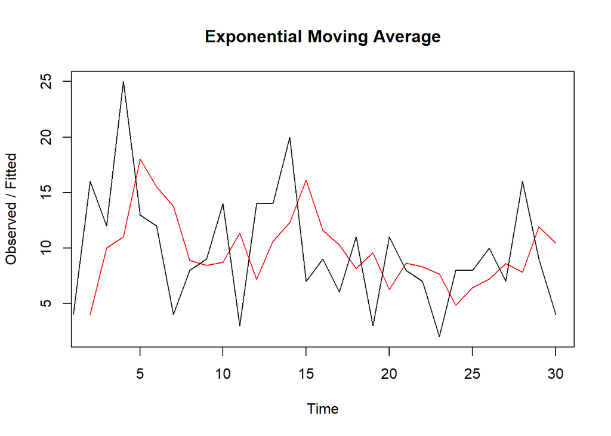

```r
# Play with the value of alpha. What happens if alpha is close to 1?
ema <- HoltWinters(demand_ts, alpha = 0.5, beta = FALSE, gamma = FALSE)
plot(ema, main = "Exponential Moving Average")
```

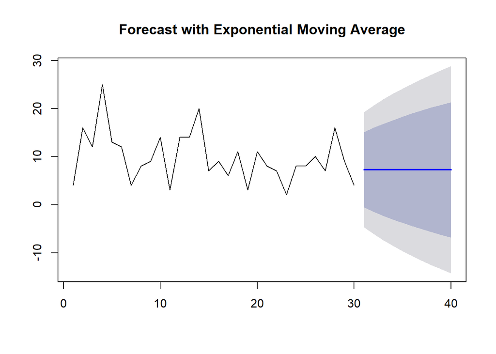

```r
ema_fc <- forecast(ema, h = 10)
plot(ema_fc, main = "Forecast with Exponential Moving Average")
```

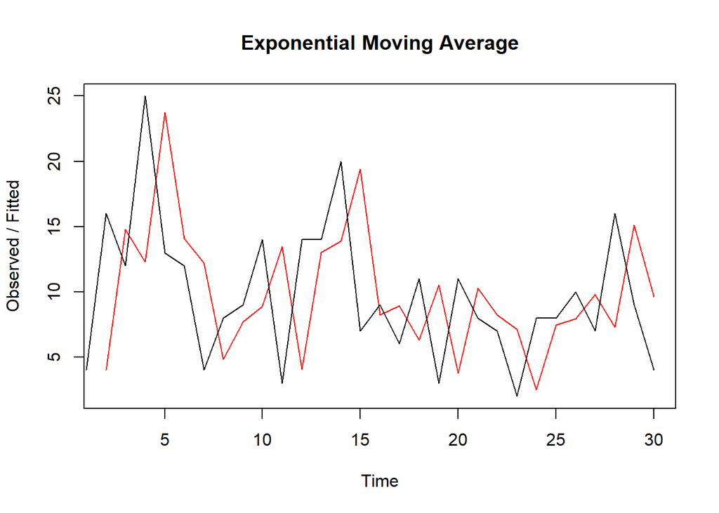

```r
# Play with the value of alpha. What happens if alpha is close to 1?
ema <- HoltWinters(demand_ts, alpha = 0.9, beta = FALSE, gamma = FALSE)
plot(ema, main = "Exponential Moving Average")
```

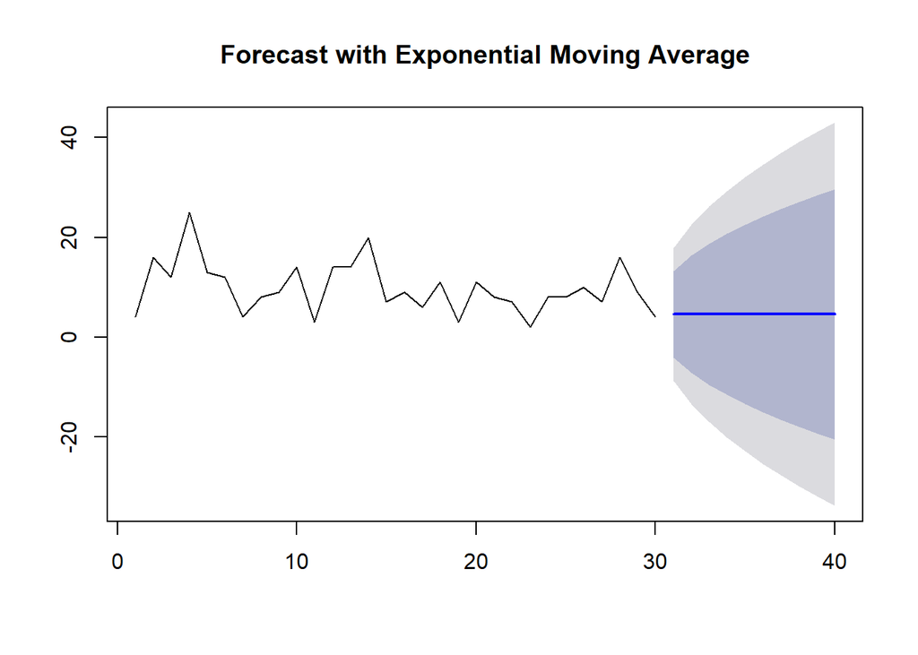

```r
ema_fc <- forecast(ema, h = 10)
plot(ema_fc, main = "Forecast with Exponential Moving Average")
```

### Double Exponential Moving Average

Is especially useful if you have data with a long term (linear) trend.

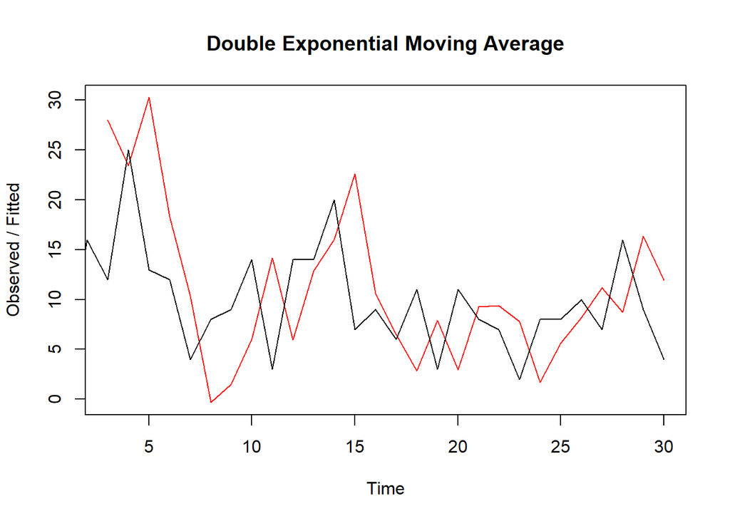

```r
dema <- HoltWinters(demand_ts, gamma = FALSE)
plot(dema, main = "Double Exponential Moving Average")
```

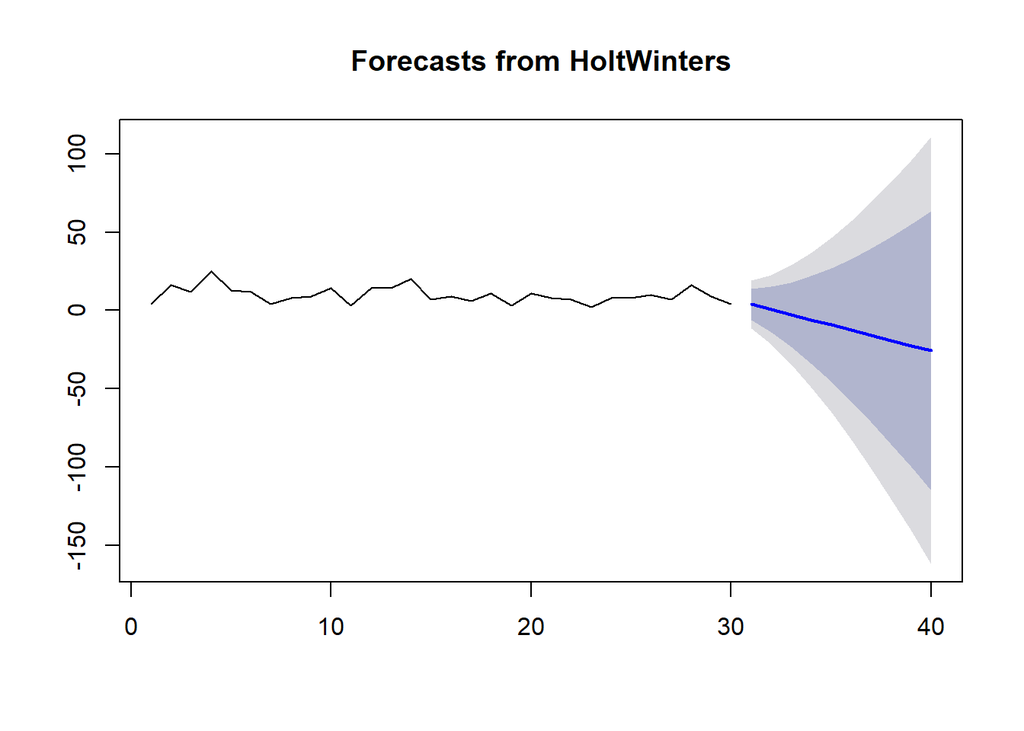

```r
dema_fc <- forecast(dema, h = 10)
plot(dema_fc)
```

### Holt-Winters Exponential Smoothing

Holt-Winter’s method is also able to model seasonal trends in data.

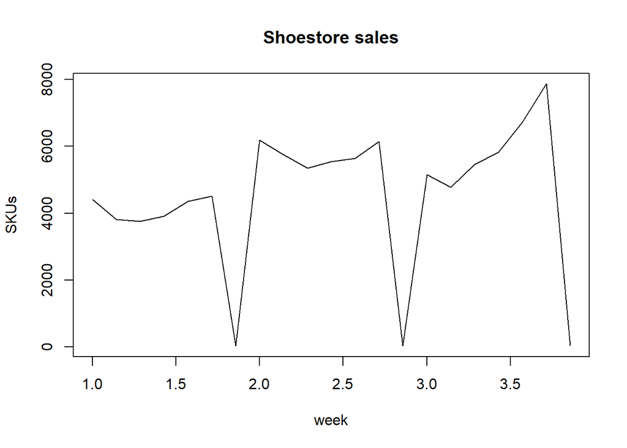

```r
sales <- read.csv('shoestore-sales.csv')
sales_ts <- ts(sales$x_t, frequency = 7, start = c(1, 1))
plot.ts(sales_ts,
        main = 'Shoestore sales',
        xlab = 'week',
        ylab = 'SKUs')
```

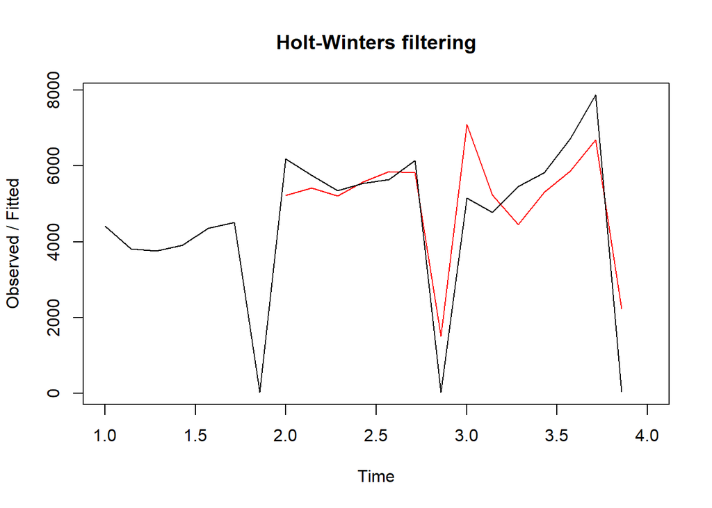

```r
hw <- HoltWinters(sales_ts)
plot(hw, xlim = c(1, 4))
```

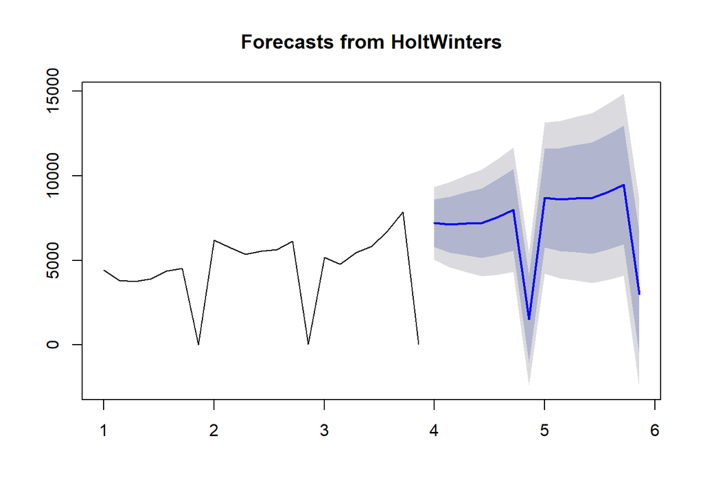

```r
sales_fc <- forecast(hw, h = 14)
plot(sales_fc)
```

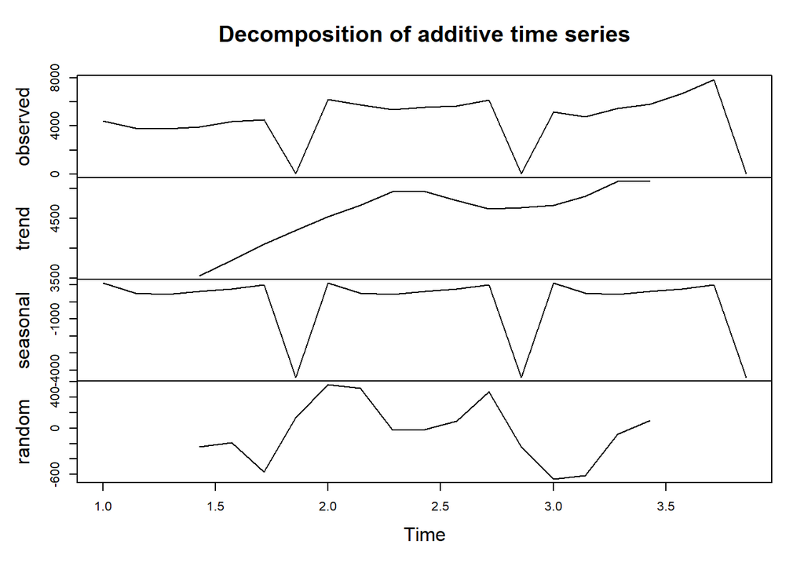

```r
sales_decomposed <- decompose(sales_ts)
plot(sales_decomposed)
```